# Through the eyes of the teacher - Multimodal exploration of expertise differences in the perception of classroom disruptions in a laboratory study

## 1. Participants

Demographic information & teaching experience

| Group | N | Women in percent | M Age in years | SD Age in years | Min Age in years | Max Age in years | M Exp. | SD Exp. | Min Exp. | Max Exp. |
| --- | --- | --- | --- | --- | --- | --- | --- | --- | --- | --- |
| Expert | 40 | 60.00 | 39.10 | 10.55 | 26 | 60 | 11.55 | 11.32 | 1 | 38 |
| Novice | 42 | 69.05 | 22.83 | 1.85 | 19 | 27 | 0.00 | 0.00 | 0 | 0 |

## 2. Measures

### 2.1 Eye-Tracking Data

#### 2.2.1 Number of fixations per minute (micro-teaching unit)

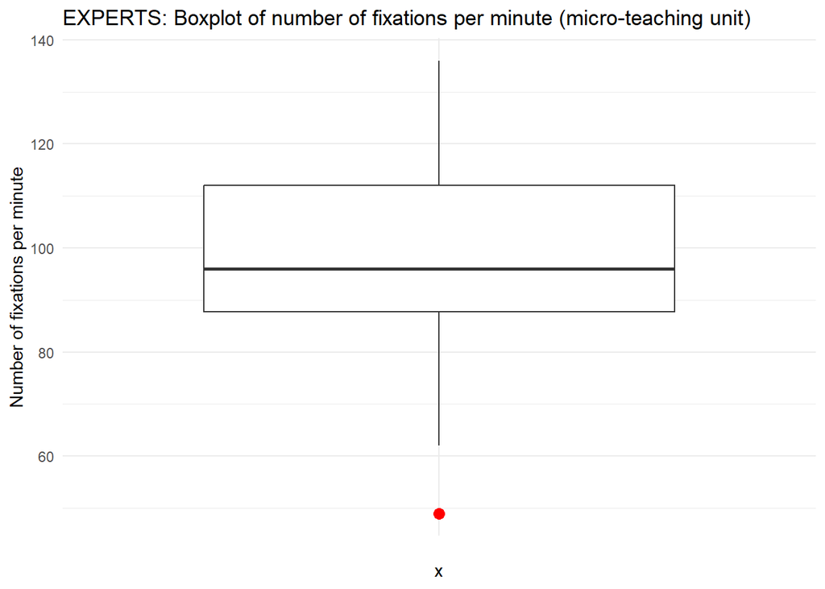

[1] 40 [1] 39

| Group | Participant | Duration_of_interval | Duration_of_interval_min | Duration_of_interval_sec | Sum_duration_fixation | Sum_average_duration_fixation | Sum_number_fixation | Average_duration_mtu | Number_fixation_sec_mtu | Number_fixation_min_mtu |
| --- | --- | --- | --- | --- | --- | --- | --- | --- | --- | --- |
| Expert | 205 | 1050304 | 17.51 | 1050.3 | 437583 | 5641 | 859 | 509 | 0.82 | 49 |

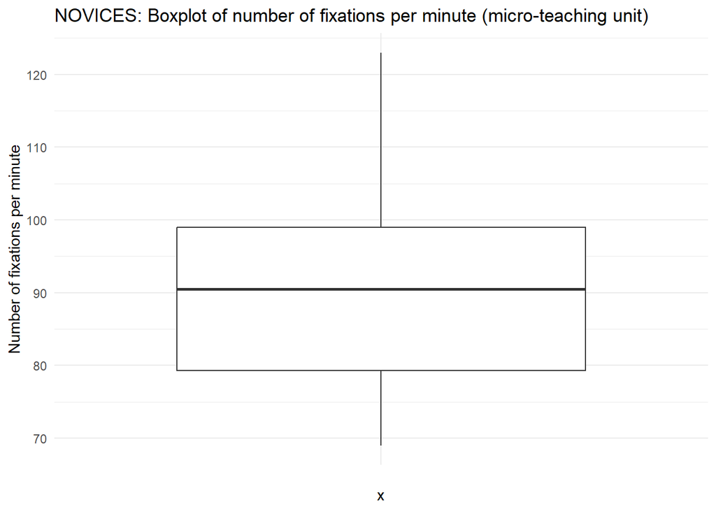

N, M, SD, min & max number of fixation per minute (micro-teaching unit)

| Group | N | M | SD | Min | Max |
| --- | --- | --- | --- | --- | --- |
| Novice | 42 | 91.26 | 14.43 | 69 | 123 |
| Expert | 39 | 99.85 | 17.48 | 62 | 136 |

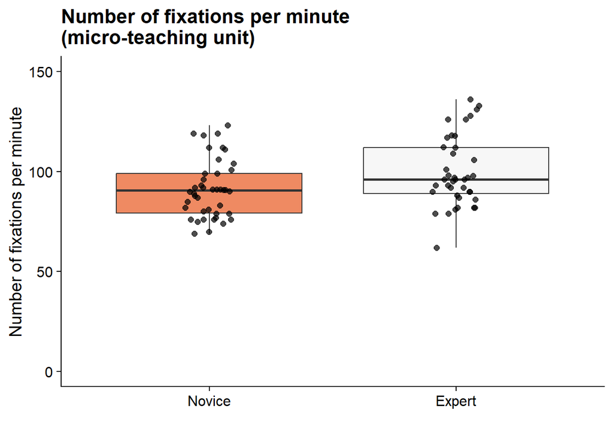

#### t-test & effect size “Number of fixation (micro-teaching unit)”

```
Two Sample t-test
```

data: df_aoi_sum_no_out$Number_fixation_min_mtu[df_aoi_sum_no_out$Group == “Expert”] and df_aoi_sum_no_out$Number_fixation_min_mtu[df_aoi_sum_no_out$Group == “Novice”] t = 2.4167, df = 79, p-value = 0.01797 alternative hypothesis: true difference in means is not equal to 0 95 percent confidence interval: 1.51394 15.65456 sample estimates: mean of x mean of y 99.84615 91.26190

[1] 0.54 attr(,“magnitude”) [1] “medium”

#### 2.2.2 Number of fixations per minute (AOI students)

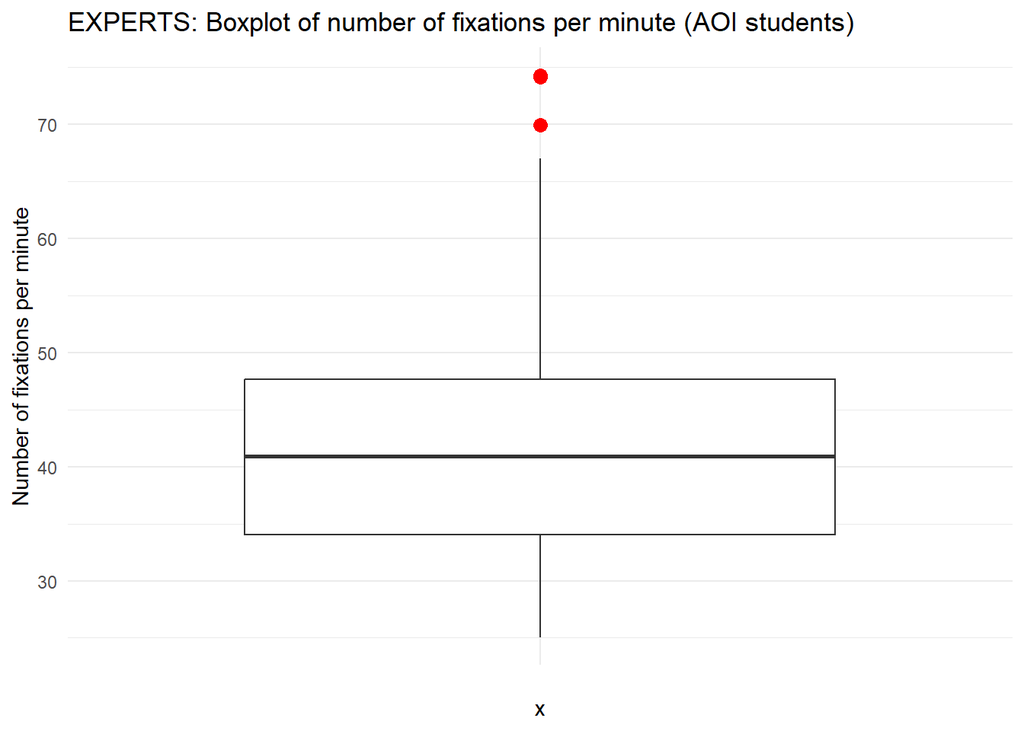

[1] 40 [1] 37

| Group | Participant | Duration_of_interval_min | Duration_of_interval_sec | Stud_duration_fixation | Stud_number_fixation | Stud_number_fixation_min | Stud_number_fixation_sec | Average_duration_stud |
| --- | --- | --- | --- | --- | --- | --- | --- | --- |
| Expert | 206 | 17.87 | 1072.23 | 438181 | 1328 | 74.31 | 1.24 | 330 |
| Expert | 236 | 17.40 | 1043.90 | 460603 | 1290 | 74.14 | 1.24 | 357 |
| Expert | 241 | 17.68 | 1060.91 | 404363 | 1237 | 69.97 | 1.17 | 327 |

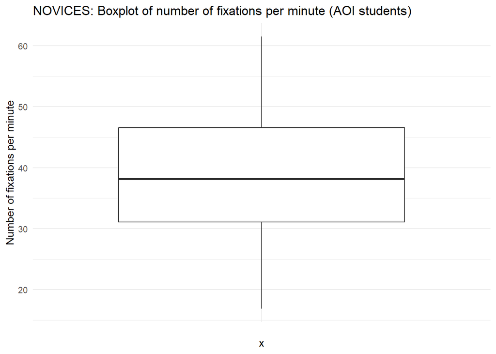

[1] 42 [1] 42

| Group | Participant | Duration_of_interval_min | Duration_of_interval_sec | Stud_duration_fixation | Stud_number_fixation | Stud_number_fixation_min | Stud_number_fixation_sec | Average_duration_stud |
| --- | --- | --- | --- | --- | --- | --- | --- | --- |

N, M, SD, min & max number of fixations per minute (AOI students)

[output not shown]

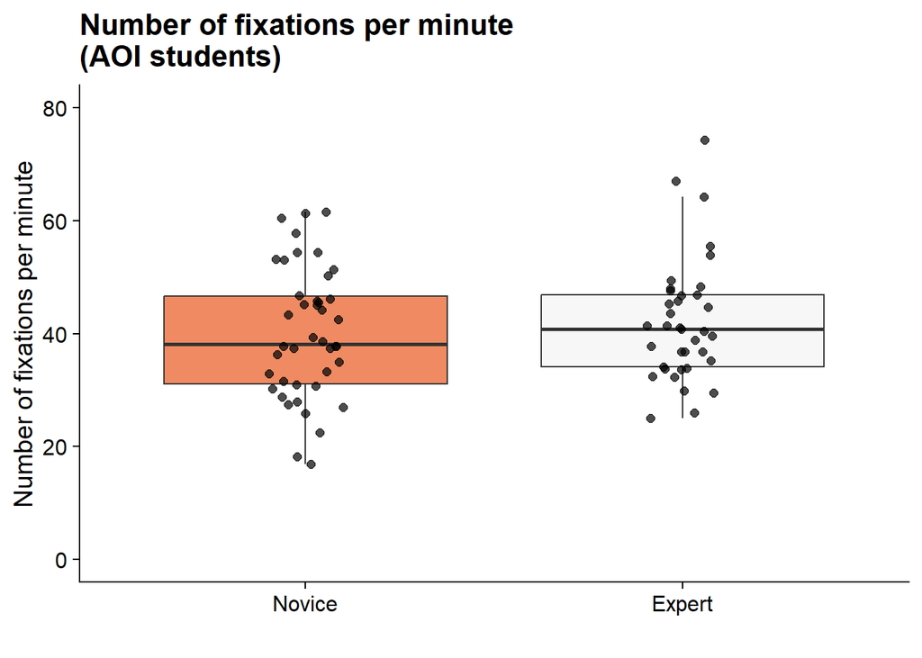

#### t-test & effect size “Number of fixation” (AOI students)

```
Two Sample t-test
```

data: df_aoi_stud_no_out$Stud_number_fixation_min[df_aoi_stud_no_out$Group == “Expert”] and df_aoi_stud_no_out$Stud_number_fixation_min[df_aoi_stud_no_out$Group == “Novice”] t = 0.8055, df = 77, p-value = 0.423 alternative hypothesis: true difference in means is not equal to 0 95 percent confidence interval: -2.998541 7.072440 sample estimates: mean of x mean of y 42.11838 40.08143

[1] 0.18 attr(,“magnitude”) [1] “negligible”

#### 2.2.3 Number of fixations (AOI disruptive person)

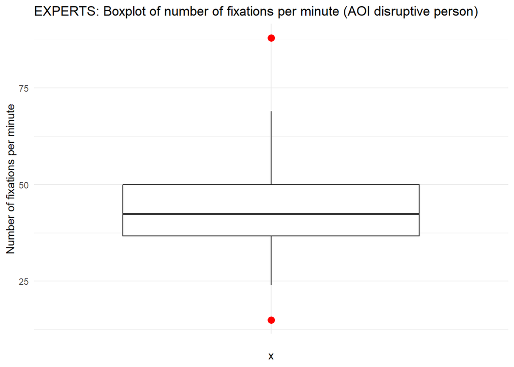

[1] 40 [1] 38

| Group | Participant | Number_of_fixations.Disruptive_Person |
| --- | --- | --- |
| Expert | 207 | 88 |
| Expert | 226 | 15 |

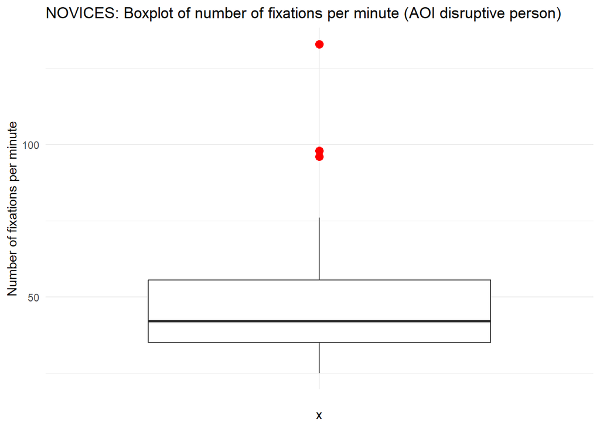

[1] 42 [1] 39

| Group | Participant | Number_of_fixations.Disruptive_Person |
| --- | --- | --- |
| Novice | 101 | 133 |
| Novice | 108 | 96 |
| Novice | 116 | 98 |

N, M, SD, min & max number of fixation (AOI disruptive person)

| Group | N | M | SD | Min | Max |
| --- | --- | --- | --- | --- | --- |
| Novice | 39 | 43.46 | 13.36 | 25 | 76 |
| Expert | 38 | 43.74 | 10.56 | 24 | 69 |

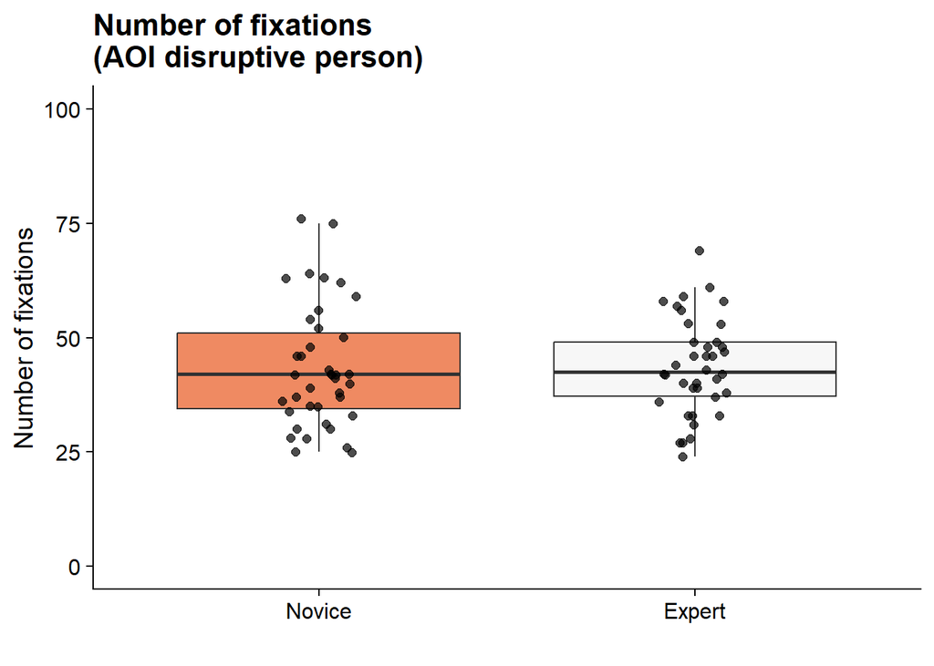

#### t-test & effect size “Number of fixations” (AOI disruptive person)

```
Two Sample t-test
```

data: df_no_outliers_disrup$Number_of_fixations.Disruptive_Person[df_no_outliers_disrup$Group == “Expert”] and df_no_outliers_disrup$Number_of_fixations.Disruptive_Person[df_no_outliers_disrup$Group == “Novice”] t = 0.10014, df = 75, p-value = 0.9205 alternative hypothesis: true difference in means is not equal to 0 95 percent confidence interval: -5.201106 5.751713 sample estimates: mean of x mean of y 43.73684 43.46154

[1] 0.02 attr(,“magnitude”) [1] “negligible”

#### 2.2.4 Average duration of fixations in milliseconds (micro-teaching unit)

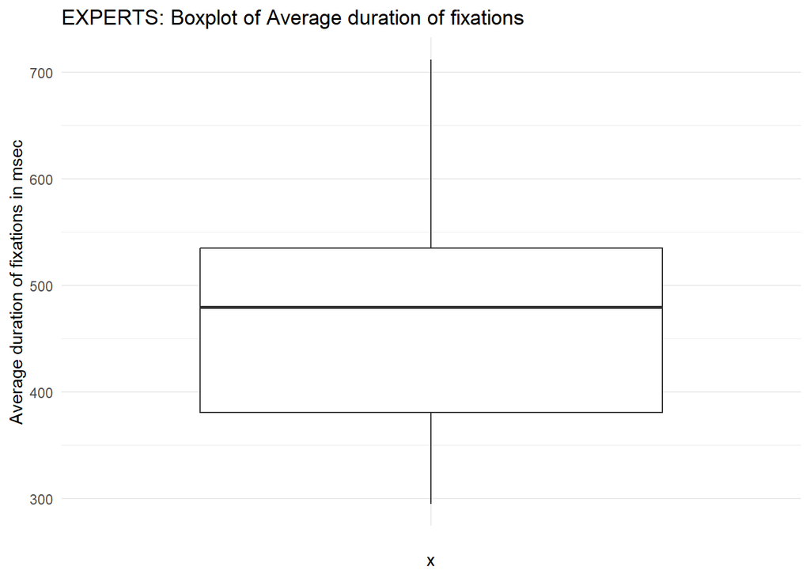

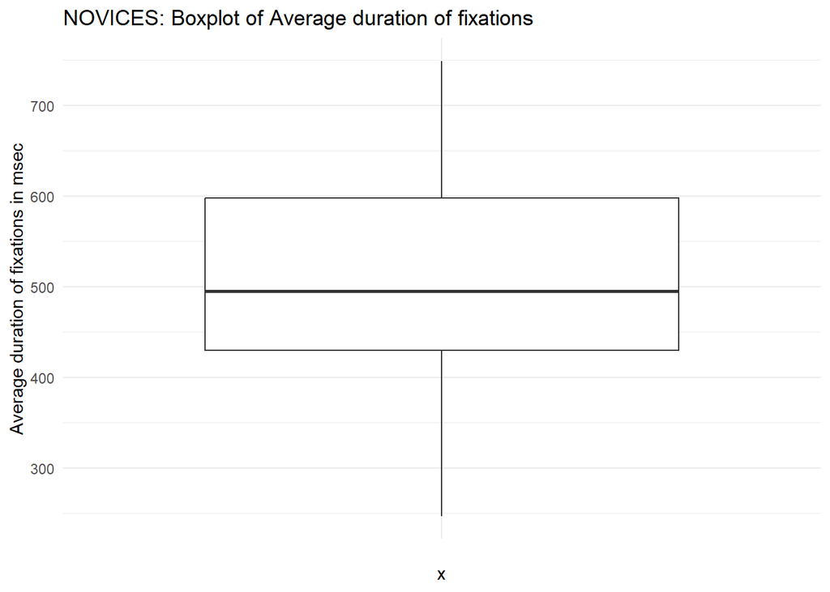

N, M, SD, min & max duration of fixations in milliseconds (micro-teaching unit)

| Group | N | M in ms | SD in ms | Min in ms | Max in ms |
| --- | --- | --- | --- | --- | --- |
| Novice | 42 | 513.81 | 117.71 | 247 | 749 |
| Expert | 40 | 472.92 | 106.18 | 295 | 712 |

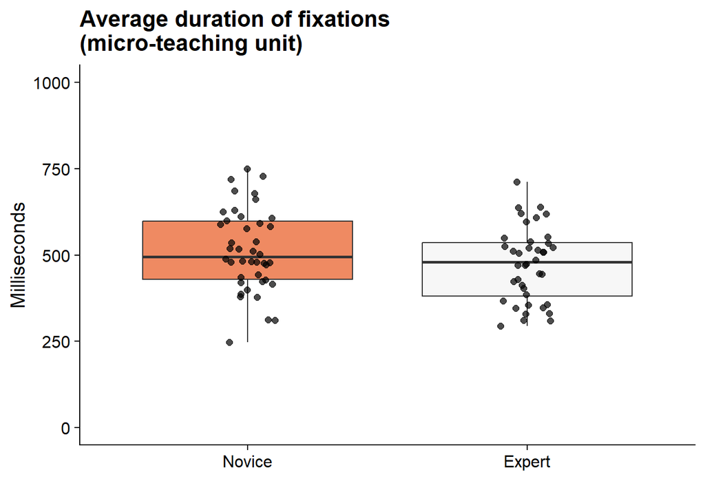

#### t-test & effect size “Average duration of fixations” (micro-teaching unit)

```
Two Sample t-test
```

data: df_aoi_sum$Average_duration_mtu[df_aoi_sum$Group == “Expert”] and df_aoi_sum$Average_duration_mtu[df_aoi_sum$Group == “Novice”] t = -1.6488, df = 80, p-value = 0.1031 alternative hypothesis: true difference in means is not equal to 0 95 percent confidence interval: -90.231822 8.462774 sample estimates: mean of x mean of y 472.9250 513.8095

[1] -0.36 attr(,“magnitude”) [1] “small”

#### 2.2.5 Average duration of fixations (AOI students)

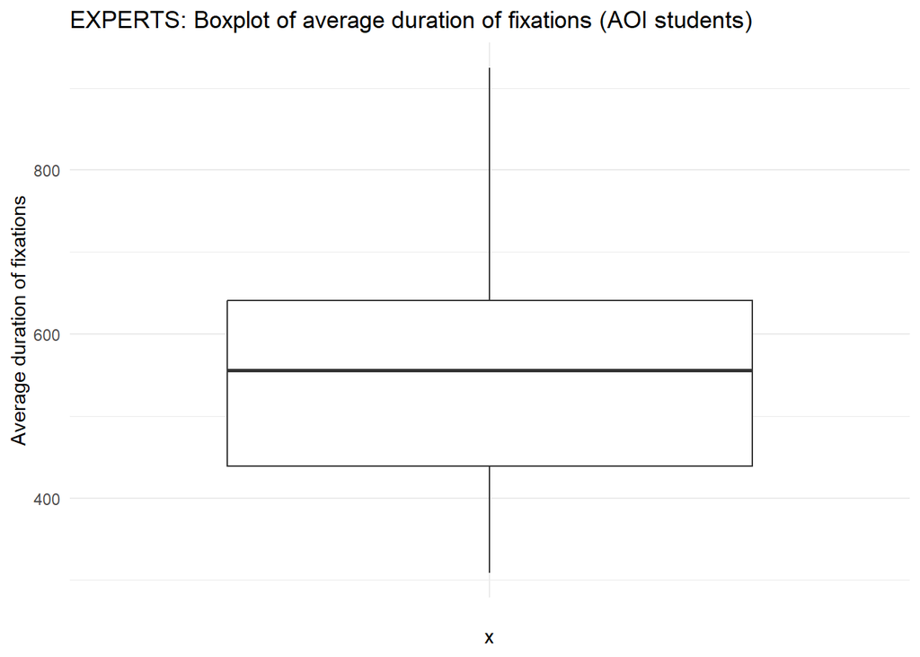

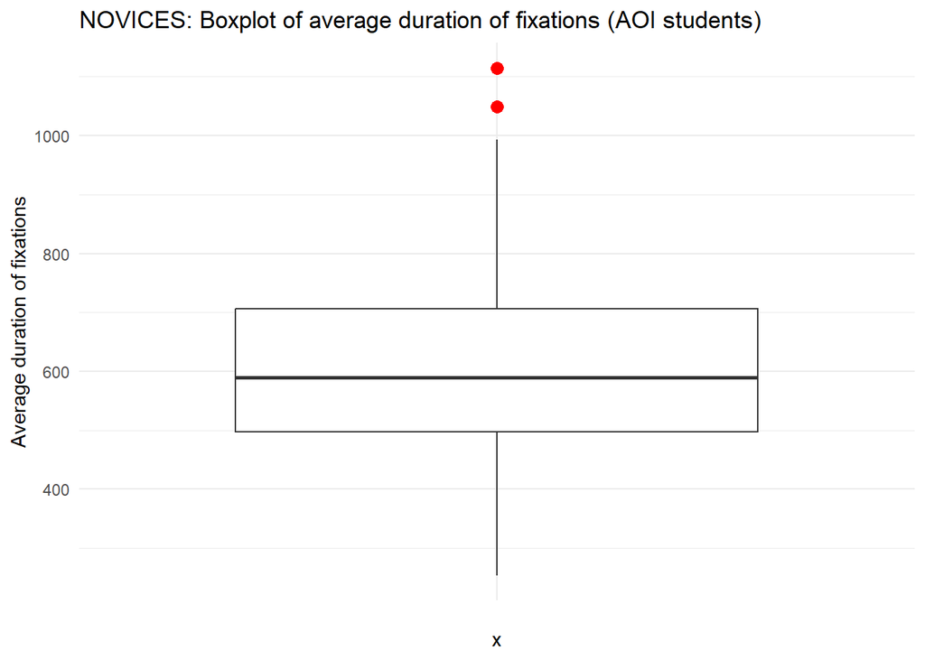

[1] 42 [1] 40

| Group | Participant | Stud_duration_fixation | Stud_number_fixation | Average_duration_stud |
| --- | --- | --- | --- | --- |
| Novice | 105 | 587631 | 560 | 1049 |
| Novice | 133 | 506242 | 454 | 1115 |

N, M, SD, min & max average duration of fixations in milliseconds (AOI students)

| Group | N | M in ms | SD in ms | Min in ms | Max in ms |
| --- | --- | --- | --- | --- | --- |
| Novice | 40 | 590.25 | 162.98 | 254 | 993 |
| Expert | 40 | 552.55 | 146.32 | 309 | 925 |

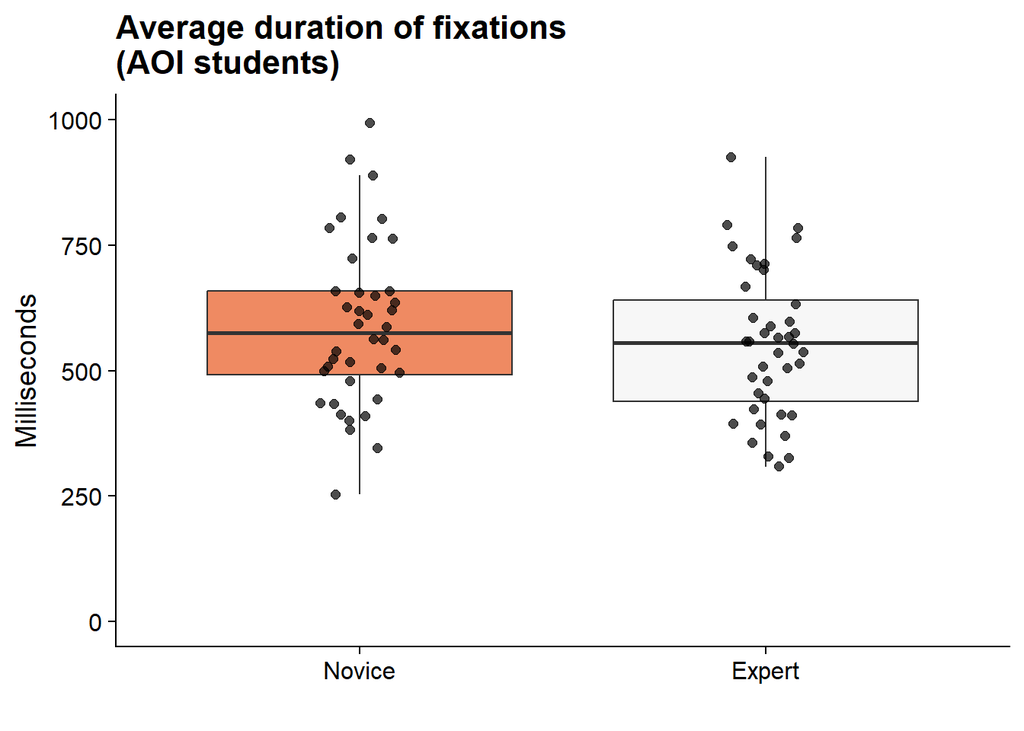

#### t-test & effect size “Average duration of fixations” (AOI students)

```
Two Sample t-test
```

data: df_no_outliers_stud_dur$Average_duration_stud[df_no_outliers_stud_dur$Group == “Expert”] and df_no_outliers_stud_dur$Average_duration_stud[df_no_outliers_stud_dur$Group == “Novice”] t = -1.0886, df = 78, p-value = 0.2797 alternative hypothesis: true difference in means is not equal to 0 95 percent confidence interval: -106.6448 31.2448 sample estimates: mean of x mean of y 552.55 590.25

[1] -0.24 attr(,“magnitude”) [1] “small”

#### 2.2.6 Average duration of fixations (AOI disruptive person)

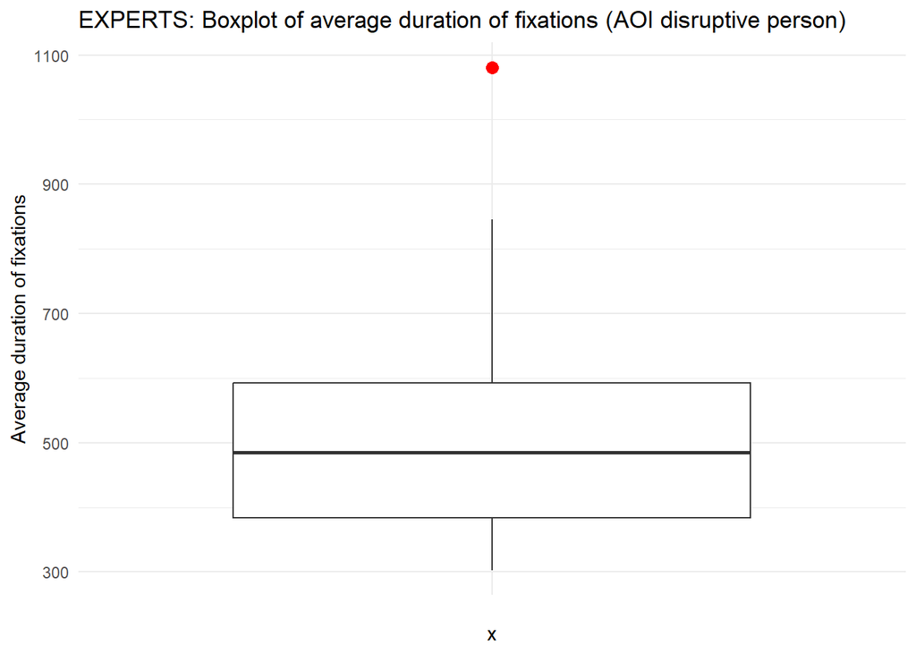

[1] 40 [1] 39

| Group | Participant | Total_duration_of_fixations.Disruptive_Person | Number_of_fixations.Disruptive_Person | Average_duration_disrup |
| --- | --- | --- | --- | --- |
| Expert | 216 | 30262 | 28 | 1081 |

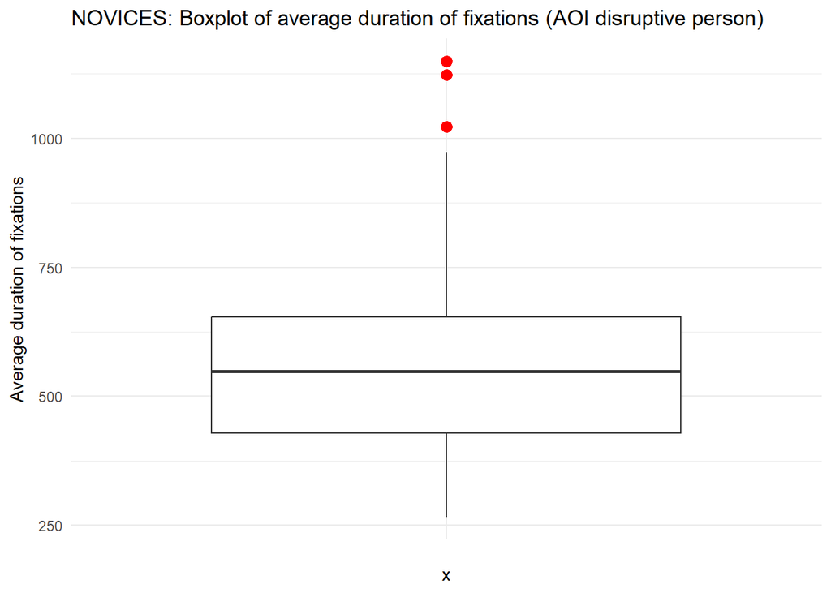

[1] 42 [1] 39

| Group | Participant | Total_duration_of_fixations.Disruptive_Person | Number_of_fixations.Disruptive_Person | Average_duration_disrup |
| --- | --- | --- | --- | --- |
| Novice | 105 | 40876 | 40 | 1022 |
| Novice | 109 | 37058 | 33 | 1123 |
| Novice | 133 | 32201 | 28 | 1150 |

N, M, SD, min & max average duration of fixations in milliseconds (AOI disruptive person)

| Group | N | M in ms | SD in ms | Min in ms | Max in ms |
| --- | --- | --- | --- | --- | --- |
| Novice | 39 | 545.05 | 166.87 | 266 | 974 |
| Expert | 39 | 488.23 | 123.70 | 303 | 845 |

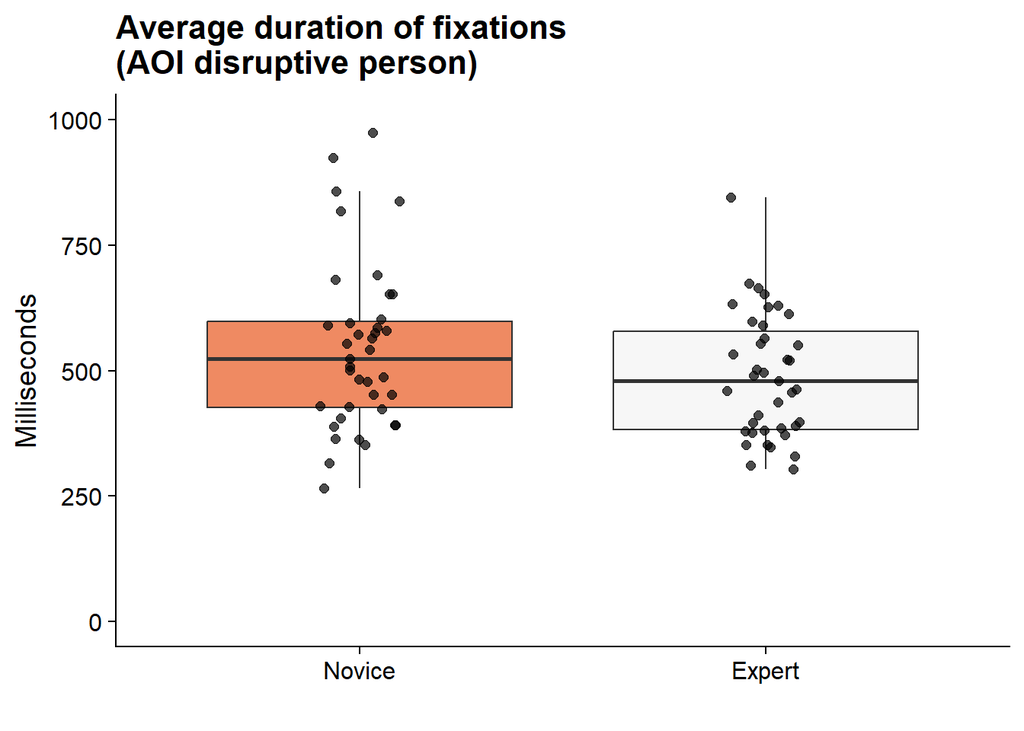

#### t-test & effect size “Average duration of fixations” (AOI disruptive person)

```
Two Sample t-test
```

data: df_no_outliers_disrup_dur$Average_duration_disrup[df_no_outliers_disrup_dur$Group == “Expert”] and df_no_outliers_disrup_dur$Average_duration_disrup[df_no_outliers_disrup_dur$Group == “Novice”] t = -1.7083, df = 76, p-value = 0.09166 alternative hypothesis: true difference in means is not equal to 0 95 percent confidence interval: -123.066443 9.425418 sample estimates: mean of x mean of y 488.2308 545.0513

[1] -0.39 attr(,“magnitude”) [1] “small”

#### 2.2.7 Gaze Relational Index (GRI; micro-teaching unit)

GRI = Average duration of fixations (mtu) / Sum number of fixations (mtu)

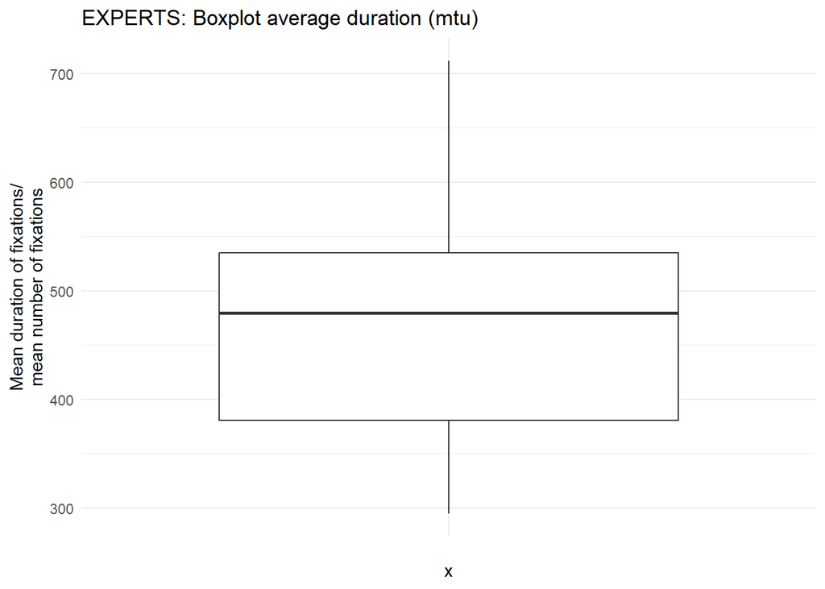

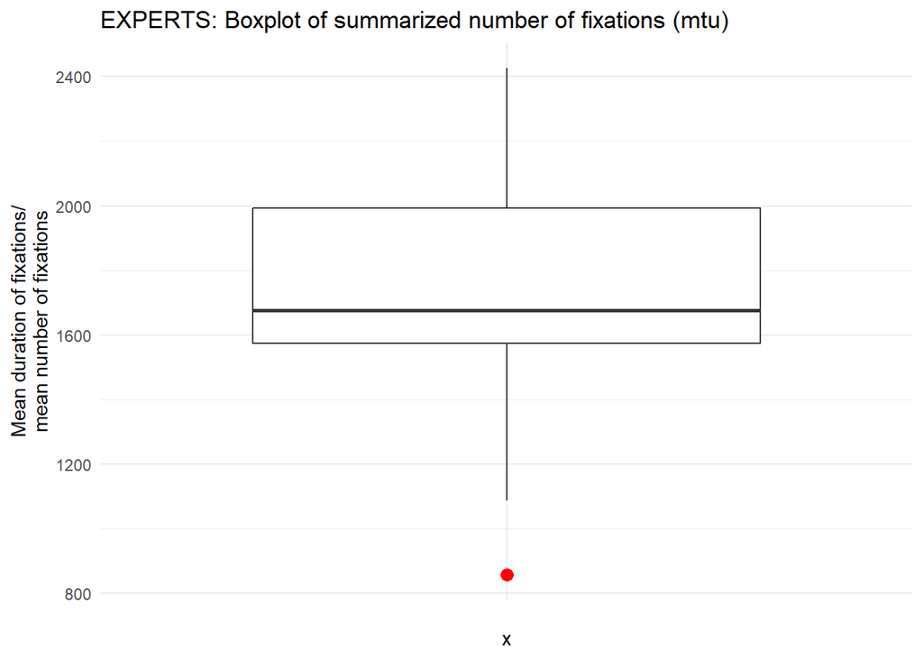

[1] 40 [1] 39

| Group | Participant | Duration_of_interval | Duration_of_interval_min | Duration_of_interval_sec | Sum_duration_fixation | Sum_average_duration_fixation | Sum_number_fixation | Average_duration_mtu | Number_fixation_sec_mtu | Number_fixation_min_mtu |
| --- | --- | --- | --- | --- | --- | --- | --- | --- | --- | --- |
| Expert | 205 | 1050304 | 17.51 | 1050.3 | 437583 | 5641 | 859 | 509 | 0.82 | 49 |

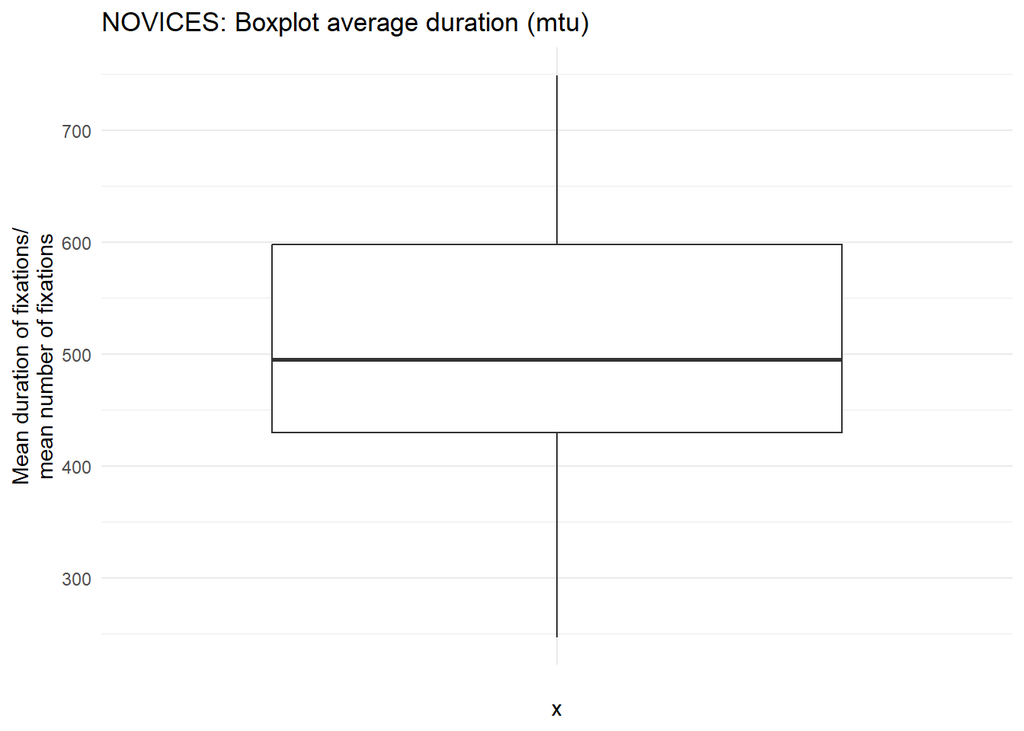

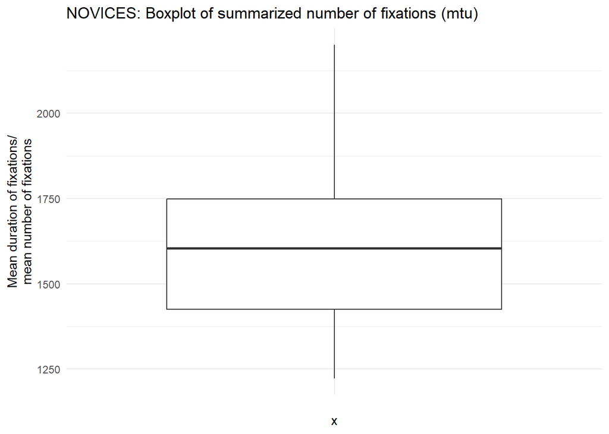

N, M, SD, min & max GRI (micro-teaching unit)

| Group | N | M | SD | Min | Max |
| --- | --- | --- | --- | --- | --- |
| Novice | 42 | 0.33 | 0.12 | 0.12 | 0.61 |
| Expert | 39 | 0.28 | 0.11 | 0.12 | 0.66 |

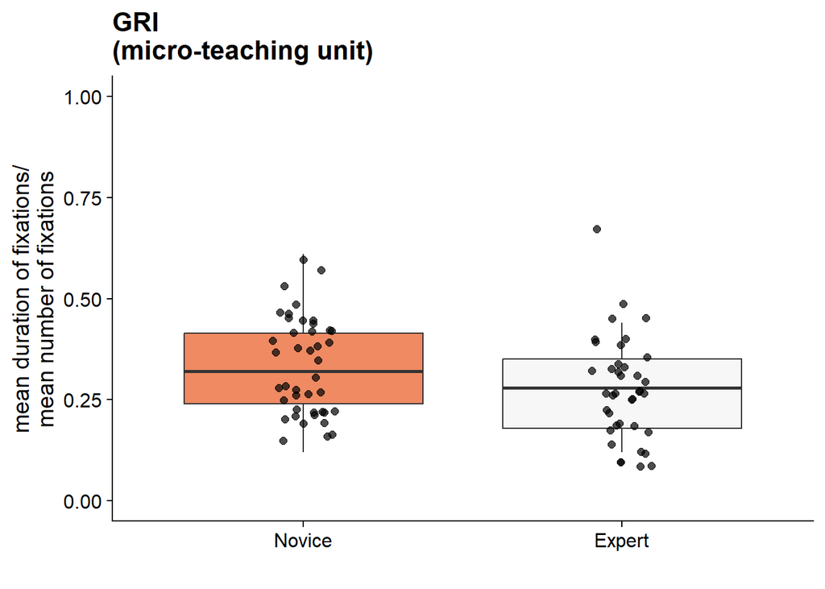

#### t-test & effect size “GRI” (micro-teaching unit)

```
Two Sample t-test
```

data: df_no_outliers_gri$GRI[df_no_outliers_gri$Group == “Expert”] and df_no_outliers_gri$GRI[df_no_outliers_gri$Group == “Novice”] t = -1.9468, df = 79, p-value = 0.05512 alternative hypothesis: true difference in means is not equal to 0 95 percent confidence interval: -0.101233411 0.001123521 sample estimates: mean of x mean of y 0.2825641 0.3326190

[1] -0.43 attr(,“magnitude”) [1] “small”

#### 2.2.10 Time to first fixation in seconds (AOI disruptive person)

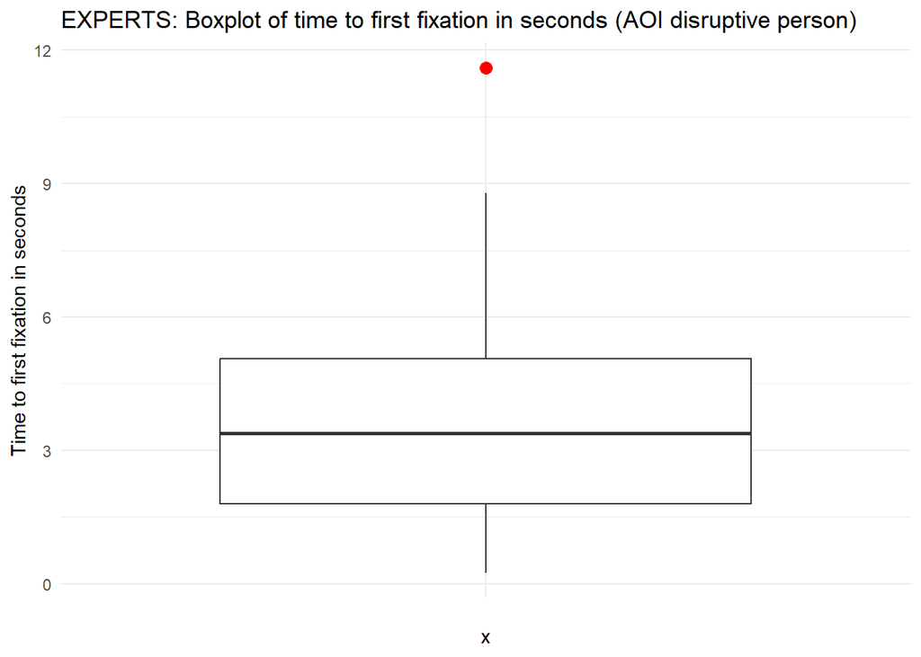

[1] 40 [1] 39

| Participant | N | Time_to_first_fixation.Disruptive_Person_Sum | Group | Sum_disruptions | Disrup_time_fixation_sec |
| --- | --- | --- | --- | --- | --- |
| 216 | 4 | 11608.25 | Expert | 558 | 11.61 |

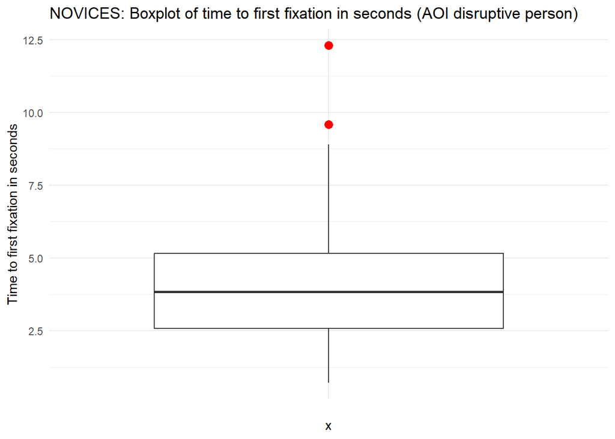

[1] 42 [1] 40

| Participant | N | Time_to_first_fixation.Disruptive_Person_Sum | Group | Sum_disruptions | Disrup_time_fixation_sec |
| --- | --- | --- | --- | --- | --- |
| 113 | 6 | 12309 | Novice | 558 | 12.31 |
| 123 | 6 | 9579 | Novice | 558 | 9.58 |

N, M, SD, min & max time to first fixation in seconds (AOI disruptive person)

| Group | N | M in sec | SD in sec | Min in sec | Max in sec |
| --- | --- | --- | --- | --- | --- |
| Expert | 39 | 3.57 | 2.18 | 0.25 | 8.78 |
| Novice | 40 | 3.79 | 1.80 | 0.72 | 8.89 |

N, M, SD, min & max of the perceived ´disruptive person´

| Group | Mean | SD | Min | Max |
| --- | --- | --- | --- | --- |
| Expert | 6.82 | 1.60 | 4 | 9 |
| Novice | 6.90 | 1.43 | 3 | 9 |

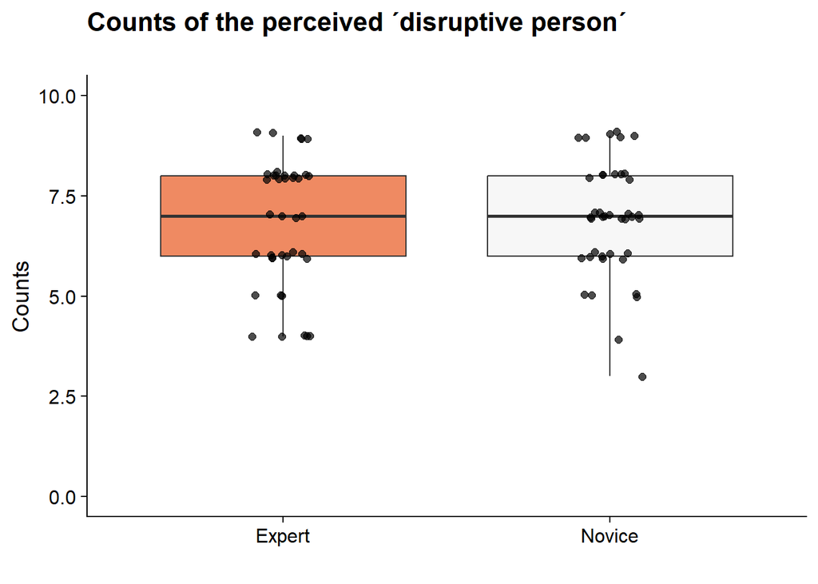

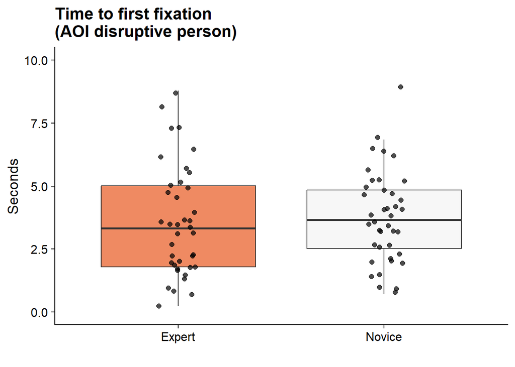